# Real_dataset_tutorial

#### 1.1 Data and Goals

Human embryonic stem cells (hESCs) typically exhibit “primed” pluripotency, analogous to stem cells derived from the mouse post-implantation epiblast. Since primed hESC have limited differentiation capacity, scientists have tried various method trying to revert “primed” hESCs to a more “naive” state which have higher pluripotency capacity (could have more clinical application potentials, and can also help us understand the early embryo development). By investigating the differentially expressed genes and their involved pathways, we can understand the mechanism undelying the differentiation capacity difference between naive hESCs and primed hESCs.

In this tutorial, we will use the 8 RNAseq dataset from *William Pastor et al., 2016, Cell Stem Cell*, with 4 replicates of naive hESCs and 4 replicates of primed hESCs.

| Accession | ID | Replicate | CellType |
| --- | --- | --- | --- |
| GSM2041708 | 1 | rep1 | Primed_hESC |
| GSM2041709 | 2 | rep2 | Primed_hESC |
| GSM2041710 | 3 | rep3 | Primed_hESC |
| GSM2041711 | 4 | rep4 | Primed_hESC |
| GSM2041712 | 5 | rep1 | Naive_hESC |
| GSM2041713 | 6 | rep2 | Naive_hESC |
| GSM2041714 | 7 | rep3 | Naive_hESC |
| GSM2041715 | 8 | rep4 | Naive_hESC |

```r
install.packages('grna')
```

```r
#read in the primed hESC RNAseq raw count
primed_hESC_rep1 <- read.delim('/Users/jesi/Documents/real_Data/GSM2041708_RNAseq_UCLA1_Primed_rep1_readsCount.txt',row.names = 1)
primed_hESC_rep2 <- read.delim('/Users/jesi/Documents/real_Data/GSM2041709_RNAseq_UCLA1_Primed_rep2_readsCount.txt',,row.names = 1)
primed_hESC_rep3  <-read.delim('/Users/jesi/Documents/real_Data/GSM2041710_RNAseq_UCLA1_Primed_rep3_readsCount.txt',row.names = 1)
primed_hESC_rep4  <-read.delim('/Users/jesi/Documents/real_Data/GSM2041711_RNAseq_UCLA1_Primed_rep4_readsCount.txt',row.names = 1)

#read in the naive hESC RNAseq raw count
naive_hESC_rep1 <- read.delim('/Users/jesi/Documents/real_Data/GSM2041712_RNAseq_SSEA4_neg_rep1_readCounts.txt',row.names = 1)
naive_hESC_rep2 <- read.delim('/Users/jesi/Documents/real_Data/GSM2041713_RNAseq_SSEA4_neg_rep2_readCounts.txt',row.names = 1)
naive_hESC_rep3  <-read.delim('/Users/jesi/Documents/real_Data/GSM2041714_RNAseq_SSEA4_neg_rep3_readCounts.txt',row.names = 1)
naive_hESC_rep4  <-read.delim('/Users/jesi/Documents/real_Data/GSM2041715_RNAseq_SSEA4_neg_rep4_readsCount.txt',row.names = 1)

head(primed_hESC_rep4)
```

|  | X116 |
| --- | --- |
| A1BG | 18 |
| A1BG-AS1 | 15 |
| A1CF | 13 |
| A2LD1 | 30 |
| A2M | 36 |
| A2ML1 | 393 |

```r
readcount = data.frame(naive_hESC_rep1,
                       naive_hESC_rep2,
                       naive_hESC_rep3,
                       naive_hESC_rep4,
                       primed_hESC_rep1,
                       primed_hESC_rep2,
                       primed_hESC_rep3,
                       primed_hESC_rep4)

colnames(readcount) = c(paste(rep('naive_hESC_rep',4),c(1:4),sep=''),paste(rep('primed_hESC_rep',4),c(1:4),sep=''))
# convert variable name as str: deparse(substitute(data))
```

```r
library(grnaeR)
library(DESeq2)
library('ggplot2')
library("pheatmap")
library("RColorBrewer")
library('AnnotationDbi')
library('org.Hs.eg.db')
```

#### 1.2 Check the data quality

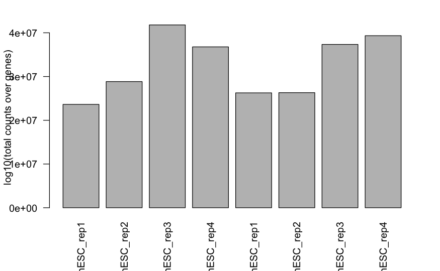

```r
total.cov = check_totalcov_quality(readcount)
```

From this plot, we can see that the coverage of all those 8 samples are in the same magnitude indicating they got sequenced evenly.

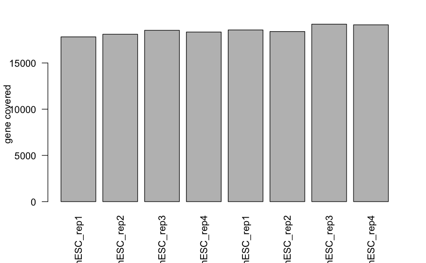

```r
gene.cov = check_genecovered_quality(readcount)
```

#### 1.2 Load data into Deseq2

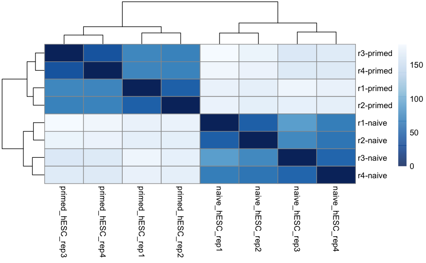

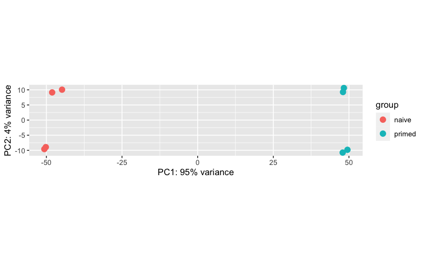

```r
condition_vector = c(c(rep('naive',4)),c(rep('primed',4)))
type_vector = c(rep(paste(rep('r',4),c(1:4),sep=''),2))

dds = load_data_for_DESeq2(readcount,condition_vector,type_vector)
normalized_dds = normalize_dataset(dds)
check_sample_distance(normalized_dds)
```

```r
select_DEGs = select_DEG(dds = dds,filter_thresh = 0,log2_fc = 1, padjust = 0.05)
```

```
[1] "filtering 2489 genes with low counts"
```

```
out of 20883 with nonzero total read count
adjusted p-value < 0.05
LFC > 1.00 (up)    : 1988, 9.5%
LFC < -1.00 (down) : 1182, 5.7%
outliers [1]       : 1, 0.0048%
low counts [2]     : 2025, 9.7%
(mean count < 1)
[1] see 'cooksCutoff' argument of ?results
[2] see 'independentFiltering' argument of ?results
```

Here, we displayed the differentially expressed genes in the primed and naive human embryonic stem cells

```r
select_DEGs
```

|  | baseMean | log2FoldChange | lfcSE | stat | pvalue | padj |
| --- | --- | --- | --- | --- | --- | --- |
| A4GALT | 398.511748 | -4.370871 | 0.2506463 | -13.448718 | 3.132572e-41 | 3.211801e-39 |
| AADAC | 3.615533 | -5.495015 | 1.3855628 | -3.244180 | 1.177893e-03 | 8.406033e-03 |
| AADACL3 | 16.371728 | 3.365400 | 0.7923113 | 2.985443 | 2.831683e-03 | 1.884823e-02 |
| AARS2 | 2285.624212 | -2.587097 | 0.2117793 | -7.494107 | 6.675119e-14 | 1.636836e-12 |
| ABCA1 | 7578.004807 | -3.240110 | 0.3196038 | -7.009022 | 2.399900e-12 | 5.166086e-11 |
| ABCA13 | 187.323098 | -2.190139 | 0.2360508 | -5.041876 | 4.609896e-07 | 5.622820e-06 |
| ABCB1 | 3.524982 | 5.064268 | 1.2967236 | 3.134259 | 1.722885e-03 | 1.193112e-02 |
| ABCB10 | 574.587749 | -1.790584 | 0.1493826 | -5.292343 | 1.207592e-07 | 1.600250e-06 |
| ABCB4 | 10.869679 | 4.185474 | 0.8504698 | 3.745546 | 1.800021e-04 | 1.507907e-03 |
| ABCB8 | 292.623634 | -2.977612 | 0.2038041 | -9.703498 | 2.913341e-22 | 1.222326e-20 |

[output cut: 990 more lines]

```r
gene_name = mapIds(org.Hs.eg.db,
                     keys = row.names(select_DEGs),
                     column = "ENTREZID",
                     keytype = "SYMBOL",
                     multiVals = "first")
target_genes = as.data.frame(cbind('symbol_name' = row.names(select_DEGs),gene_name))
target_genes <- target_genes[complete.cases(target_genes), ]

DEGS <- subset(normalized_dds@assays@data@listData[[1]],rownames(normalized_dds@assays@data@listData[[1]]) %in% rownames(target_genes)==TRUE)
```

```r
DEG_genename <- c()
for(i in rownames(DEGS)){
  genename = subset(target_genes,symbol_name == i)$gene_name
  DEG_genename <- c(DEG_genename,genename)
}
rownames(DEGS) <- DEG_genename
naive_mean <- rowMeans(DEGS[,1:4])
edo <- filter_genelist(naive_mean,standard_fc = 2)
```

```
[1] "enrichResult object generated"
```

We can see that the differentially expressed genes in naive cells are involved in following enriched terms. It depicts the enrichment scores (e.g. p values) and gene count or ratio as bar height and color.

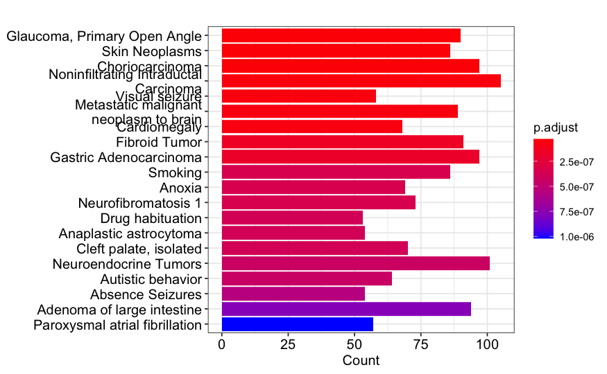

```r
barplot <- show_barplot(edo,showCategory_num = 20)
barplot
```

And we can view the over representation analysis and gene set enrichment analysis in the naive human embryonic stem cells, to see the enriched pathways.

```r
dotplot <- show_dotplot(edo,showCategory_num=30)
```

```
preparing geneSet collections...
GSEA analysis...
Warning: For some pathways, in reality P-values are less than 1e-10. You can set the `eps` argument to zero for better estimation.leading edge analysis...
done...
```

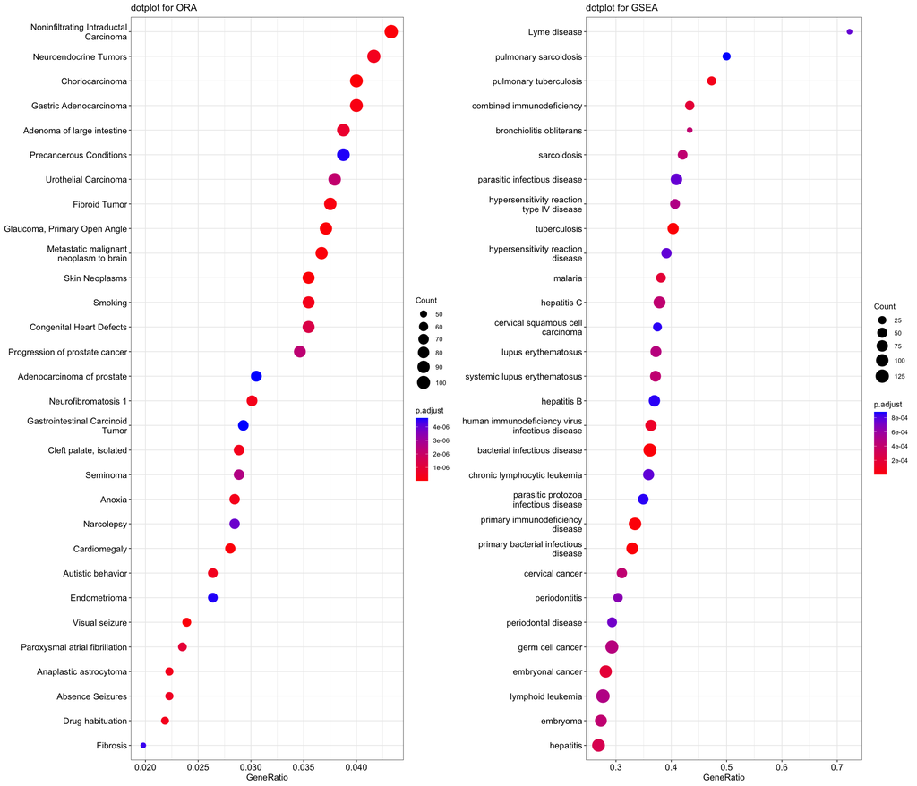

```r
dotplot
```

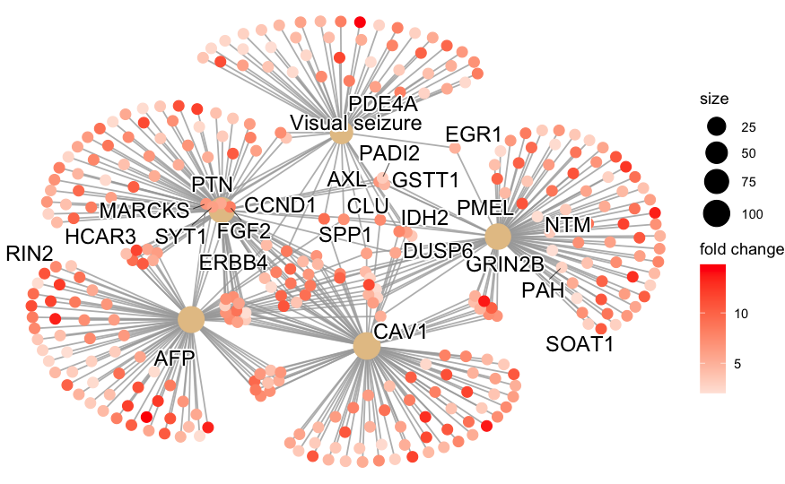

```r
gene_network <-develop_Gene_Network(edo,naive_mean)
gene_network <-develop_Gene_Network(edo,naive_mean)
gene_network
```